# gibbonsecr: GUI User Manual

2015-09-21

1. Overview

2. Launching the software

3. Data import

4. Model specification

5. Plotting results

## 1. Overview

The `gibbonsecr` software package uses Spatially Explicit Capture–Recapture (SECR) methods to estimate the density of gibbon populations from acoustic survey data. This manual begins with a brief introduction to the theory behind SECR and then describes the main components of the software.

### Introduction to SECR

Over the past decade SECR has become an increasingly popular tool for wildlife population assessment and has been successfully applied to a diverse range of taxa. The main advantage of SECR over traditional capure-recapture techniques is that it allows direct estmation of population **density** rather than abundance. Density estimation is only acheieveable in traditional capture-recapture methods through the use of separate estimates (or assumptions) about the size of the sampled area. In SECR however, this is achieved by using the information contained in the pattern of the recapture data, relative to the locations of the detectors, to make inferences about the spatial location of animals. By extracting spatial information in this way SECR can provide estimates of density without requiring the exact locations of the detected animals to be known in advance.

The basic data collection setup for an SECR analysis consists of a spatial array of **detectors**. Detectors come in a variety of different forms, including traps which physically detain the animals, and *proximity* detectors which do not. In the case of proximity detectors it is possible for an animal to be detected at more than one detector (i.e. recaptured) in a single sampling occasion.

The plot below shows a hypothetical array of proximity detectors.

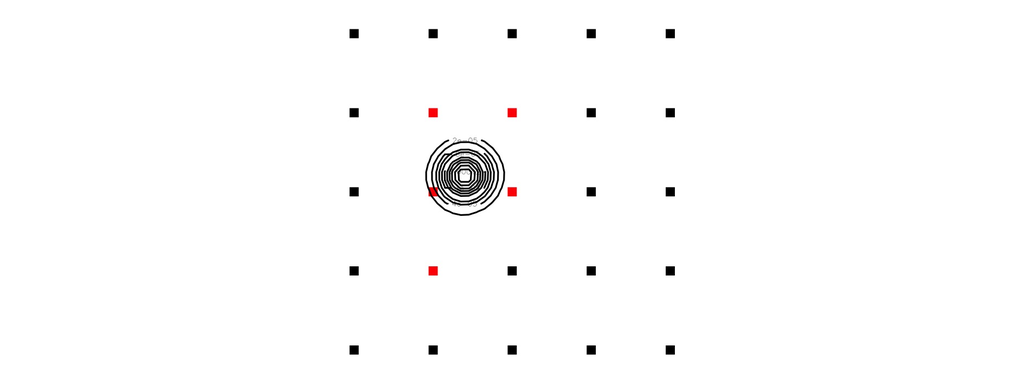

The red squares represent detections of the same animal (or the same group in the case of gibbons) and the contour lines show the probability contours for the unknown location of the animal (or group).

In the case of acoustic gibbon surveys the listening posts can be treated as proximity detectors and the same logic can be applied to infer the unknown locations of the detected groups. However, the design above would obviously be impractical for gibbon surveys. The next figure shows a more reslistic array of listening posts where a group has been detected at two of the posts.

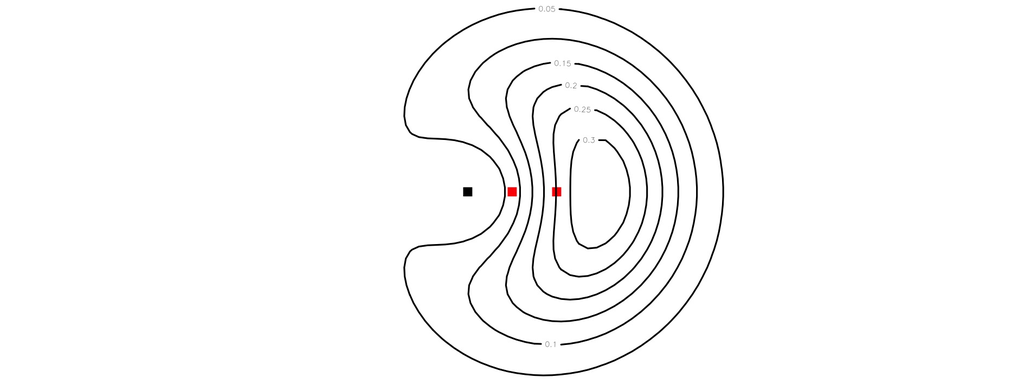

As implied by the shape of the probability contours in this example, fewer posts results in less information on the unknown locations. However, SECR also allows additional information on group location to be included in the analysis – for example in the form of **estimated bearings** to the detected animals/groups. The next figure illustrates how taking account of information contained in the estimated bearings can provide better quality information on animal/group locations.

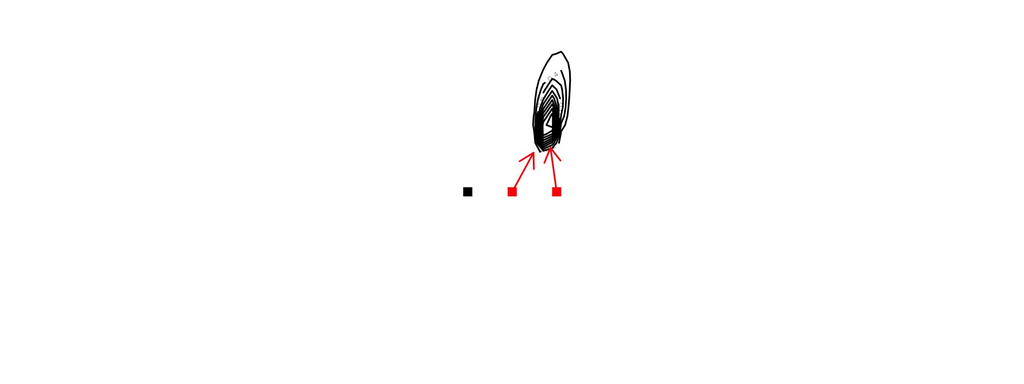

Using estimated bearings in this way can lead to density estimates that are less biased and more precise than using recapture data alone. Since the precision of bearing estimates is usually unknown, SECR methods need to estimate it from the data. This requires the choice of a **bearing error distribution**. The figure below shows two common choices of distribution for modelling bearing errors, with red lines indicating higher precision. The shape of each distribution is determined by the value of a parameter.

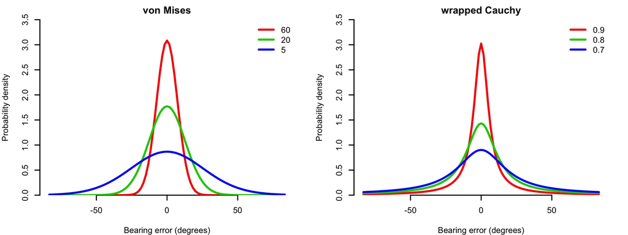

Another key feature of SECR is that the probability of detecting a (calling) gibbon group at a given location is modelled as a function of distance from the detector. This function – referred to as the **detection function** – is typically assumed to belong to one of two main types of function: the **half normal** or the **hazard rate**. The specific shape of the detection function depends on the value of its parameters. The half normal has two parameters: `sigma` and `g0`. The `sigma` parameter controls the width of the function and `g0` controls the probability at zero distance (see the plot below). The hazard rate also has these parameters in additon to a third parameter called `z` which controls the shape of the shoulder and adds a greater degree of flexibility.

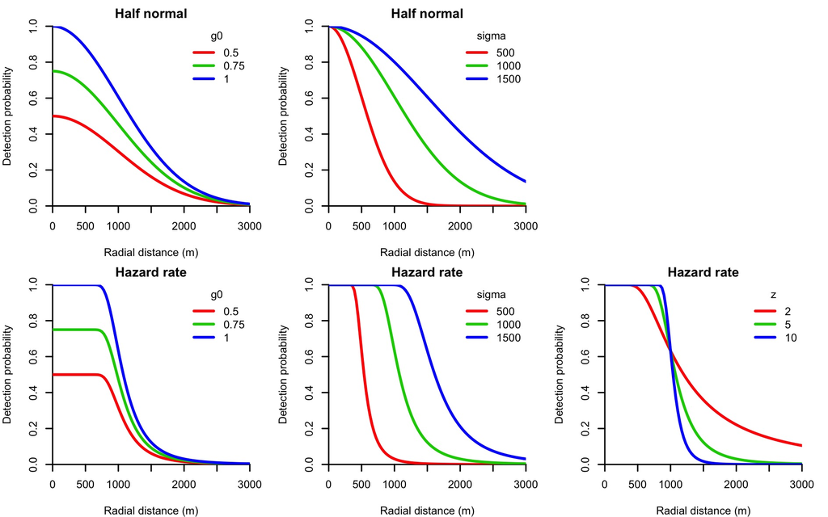

(Back to top)

## 2. Launching the software

(Back to top)

## 3. Data import

(Back to top)

## 4. Model specification

(Back to top)

## 5. Plotting results

(Back to top)